Sometimes when making a graphic, you want to change some aspect of it or add new elements to it. To illustrate, here are commands for making simple density plot in the ordinary way.

```
gf_density( ~ height + fill:"black", data = Galton) %>%
gf_density( ~ height + fill:sex, alpha = 0.25, data = Galton)
```

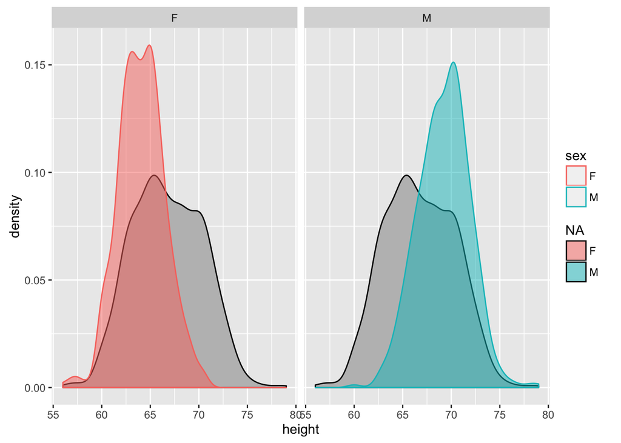

```r
ggplot() +
  geom_density(data = select(Galton, height), aes(x = height), fill = "gray") +
  geom_density(data = Galton, aes(x = height, fill = sex, color = sex), alpha = .5) +
  facet_wrap( ~ sex)
```

In looking at the plot, you realize that you want a better label for the horizontal axis. You can do this by *adding* on a new component to the plot specifying the axis label.

```
gf_density( ~ height, data = Galton) + xlab("Child's height (in)")
```

Use the `+` sign to add components that don’t start with `gf_` such as `xlab()`, `ylab()`, `facet_wrap()`, and so on. Now suppose you decide to superimpose density plots of the mothers’ and fathers’ heights. To plot each of these variables individually, you would use a command like this:

```
gf_density( ~ mother, data = Galton)
```

But we want to overlay the distribution of both the fathers and mothers so we can readily compare them to the children. For this purpose, a bit of data wrangling is required: creating one variable with the parents’ heights and another indicating the sex of the parent.

```r
Parents <-
  Galton %>%
  group_by(family) %>%
  filter(row_number() == 1) %>%
  ungroup() %>%
  select(father, mother) %>%
  tidyr::gather(key = parent, value = parent_height, father, mother)
```

You can add this component to the graph by connecting it to the previous components. Use `%>%` to add a component that does start with `gf_`.

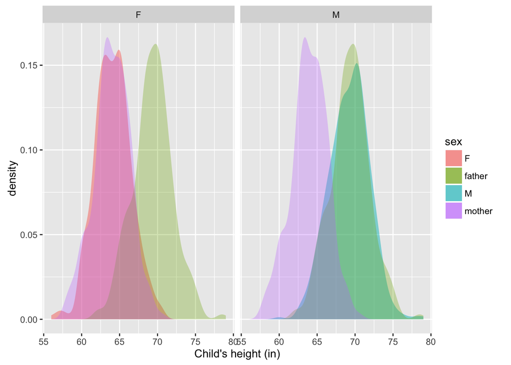

```r
gf_density( ~ height + fill:sex, alpha = 0.5, color = NULL, data = Galton) %>%
  gf_density( ~ parent_height + fill:parent, alpha = 0.3, color = NULL, data = Parents) +
  xlab("Child's height (in)") +
  facet_wrap( ~ sex)
```

Data wrangling can be an important part of preparing data to be graphed.